# Lab 2

Jared McMullen

10/3/2021

```r
library(tidyverse)
```

# Assignment

## Summary

```r
hiphop <- read_csv("hiphop.csv")
summary(hiphop)
```

```
##      word               subj               sex                 age
##  Length:10752       Length:10752       Length:10752       Min.   :16.00
##  Class :character   Class :character   Class :character   1st Qu.:18.00
##  Mode  :character   Mode  :character   Mode  :character   Median :19.00
##                                                           Mean   :20.02
##                                                           3rd Qu.:20.00
##                                                           Max.   :48.00
##
##     ethnic               city             county             intl
##  Length:10752       Min.   :      0   Min.   :      0   Min.   : 0.0000
##  Class :character   1st Qu.:  12807   1st Qu.:  99905   1st Qu.: 0.0000
##  Mode  :character   Median :  42322   Median : 331582   Median : 0.0000
##                     Mean   : 159130   Mean   : 509216   Mean   : 0.3869
##                     3rd Qu.: 103486   3rd Qu.: 959521   3rd Qu.: 0.0000
##                     Max.   :8391881   Max.   :3053793   Max.   :15.0000
##
##      vocal          classical            folk             rock
##  Min.   : 0.000   Min.   : 0.0000   Min.   :0.0000   Min.   : 0.000
##  1st Qu.: 0.000   1st Qu.: 0.0000   1st Qu.:0.0000   1st Qu.: 0.000
##  Median : 0.000   Median : 0.0000   Median :0.0000   Median : 1.000
##  Mean   : 1.089   Mean   : 0.8095   Mean   :0.3988   Mean   : 2.274
##  3rd Qu.: 1.000   3rd Qu.: 0.0000   3rd Qu.:0.0000   3rd Qu.: 4.000
##  Max.   :11.000   Max.   :10.0000   Max.   :6.0000   Max.   :18.000
##
##     country            pop          alternative         hiphop
##  Min.   :0.0000   Min.   : 0.000   Min.   : 0.000   Min.   : 0.000
##  1st Qu.:0.0000   1st Qu.: 0.000   1st Qu.: 0.000   1st Qu.: 0.000
##  Median :0.0000   Median : 1.000   Median : 2.000   Median : 0.000
##  Mean   :0.6667   Mean   : 1.238   Mean   : 2.196   Mean   : 1.595
##  3rd Qu.:0.0000   3rd Qu.: 2.000   3rd Qu.: 4.000   3rd Qu.: 3.000
##  Max.   :7.0000   Max.   :11.000   Max.   :13.000   Max.   :10.000
##
##  unclassifiable     countyBlack          jayz          barkley
##  Min.   :0.00000   Min.   :     0   Min.   :1.000   Min.   :1.000
##  1st Qu.:0.00000   1st Qu.:   675   1st Qu.:1.000   1st Qu.:1.000
##  Median :0.00000   Median :  7748   Median :5.000   Median :1.000
##  Mean   :0.05357   Mean   : 46404   Mean   :3.839   Mean   :1.804
##  3rd Qu.:0.00000   3rd Qu.: 50842   3rd Qu.:5.000   3rd Qu.:3.000
##  Max.   :1.00000   Max.   :942470   Max.   :5.000   Max.   :5.000
##
```

[output cut: 25 more lines]

```
##  Min.   :1.000   Min.   : 1.00   Min.   :0.00   Min.   :  0.00
##  1st Qu.:1.000   1st Qu.:16.75   1st Qu.:0.00   1st Qu.:  0.00
##  Median :1.000   Median :32.50   Median :0.00   Median : 21.00
##  Mean   :1.818   Mean   :32.50   Mean   :0.24   Mean   : 27.64
##  3rd Qu.:1.000   3rd Qu.:48.25   3rd Qu.:0.00   3rd Qu.: 42.50
##  Max.   :5.000   Max.   :64.00   Max.   :1.00   Max.   :120.00
##
##  numPreferredArtists numOverallArtists
##  Min.   :0.000       Min.   : 0.000
##  1st Qu.:0.000       1st Qu.: 0.000
##  Median :0.000       Median : 3.000
##  Mean   :0.338       Mean   : 5.953
##  3rd Qu.:0.000       3rd Qu.: 8.000
##  Max.   :6.000       Max.   :28.000
##  NA's   :5632        NA's   :5632
```

```r
head(hiphop, 5)
```

```
## # A tibble: 5 × 38
##   word   subj  sex     age ethnic  city county  intl vocal classical  folk  rock
##   <chr>  <chr> <chr> <dbl> <chr>  <dbl>  <dbl> <dbl> <dbl>     <dbl> <dbl> <dbl>
## 1 [to b… p15   Fema…    20 white  33283 1.16e6     0     0         0     0     1
## 2 [to b… p53   Fema…    17 white  34033 3.96e5     0     0         0     0     0
## 3 [to b… p136  Male     41 white   8789 5.87e4     0     2         0     0     0
## 4 [to b… p36   Fema…    18 white    712 1.49e5     0     0         0     1     1
## 5 [to b… p118  Fema…    18 white  24280 1.54e5     0     3         3     0     1
## # … with 26 more variables: country <dbl>, pop <dbl>, alternative <dbl>,
## #   hiphop <dbl>, unclassifiable <dbl>, countyBlack <dbl>, jayz <dbl>,
## #   barkley <dbl>, boondocks <dbl>, monique <dbl>, bieber <dbl>,
## #   asianMove <dbl>, blackMove <dbl>, hispanicMove <dbl>, nativeMove <dbl>,
## #   SAAMEMove <dbl>, whiteMove <dbl>, blackWeekly <dbl>, jayz1 <dbl>,
## #   boondocks1 <dbl>, familiarity <dbl>, trial <dbl>, fam1 <dbl>,
## #   popularityScore <dbl>, numPreferredArtists <dbl>, numOverallArtists <dbl>
```

```r
spec(hiphop)
```

**1. Through analyzing the dataset there appears to be a substantial amount of categorical variables. The dataset transitions from demographic to psychographic as you transition from left to right. Each assigned subject will have 64 rows of data.**

```r
hiphop_clean <-
  hiphop %>%
  drop_na() %>%
  mutate(
    subj = as.factor(subj),
    fam1 = as.factor(fam1),
    sex = as.factor(sex),
    ethnic = as.factor(ethnic),
    jayz1 = as.factor(jayz1),
    boondocks1 = as.factor(boondocks1)
  )
```

```r
hiphop_distinct <-
  hiphop %>%
  select(word) %>%
  distinct()
unique(count(hiphop_distinct))
```

```
## # A tibble: 1 × 1
##       n
##   <int>
## 1    64
```

**There are 64 unique AAE terms in the dataset.**

```r
hiphop_clean <-
  hiphop %>%
  mutate(ethnic = case_when(ethnic =="white" ~ "white", TRUE ~ "non-white")
  )
```

```r
hiphop_clean <-
  hiphop %>%
  select(sex, age, ethnic, subj) %>%
  distinct(subj, .keep_all = TRUE) %>%
  mutate(ethnic = case_when(ethnic =="white" ~ "white", TRUE ~ "non-white")
  ) %>%
  arrange(subj)

summary(hiphop_clean)
```

```
##      sex                 age           ethnic              subj
##  Length:168         Min.   :16.00   Length:168         Length:168
##  Class :character   1st Qu.:18.00   Class :character   Class :character
##  Mode  :character   Median :19.00   Mode  :character   Mode  :character
##                     Mean   :20.02
##                     3rd Qu.:20.00
##                     Max.   :48.00
```

```r
hiphop_clean %>%
  count(sex)
```

```
## # A tibble: 2 × 2
##   sex        n
##   <chr>  <int>
## 1 Female   117
## 2 Male      51
```

```r
hiphop_clean %>%
  count(ethnic)
```

```
## # A tibble: 2 × 2
##   ethnic        n
##   <chr>     <int>
## 1 non-white    33
## 2 white       135
```

```r
hiphop_clean %>%
  count(age)
```

```
## # A tibble: 21 × 2
##      age     n
##    <dbl> <int>
##  1    16     3
##  2    17    11
##  3    18    69
##  4    19    35
##  5    20    16
##  6    21    13
##  7    22     5
##  8    23     1
##  9    24     2
## 10    25     1
## # … with 11 more rows
```

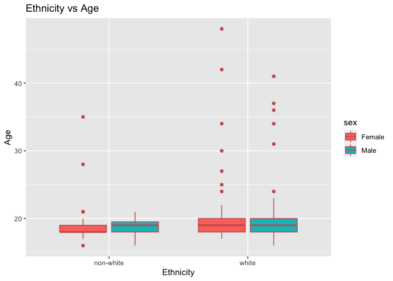

```r
#Plot number 1

ggplot(data = hiphop_clean, aes(x = as.factor(ethnic), y = age, fill = sex))+
geom_boxplot(color = 'indianred') +
ggtitle("Ethnicity vs Age")+
ylab("Age")+
xlab("Ethnicity")
```

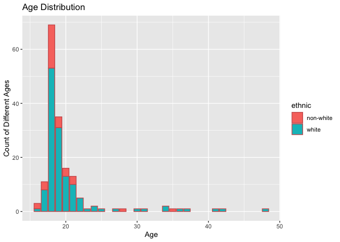

```r
#Plot Number 2

ggplot(data = hiphop_clean, aes(x = age, fill = ethnic))+
geom_bar(color = 'indianred') +
ggtitle("Age Distribution")+
ylab("Count of Different Ages")+
xlab("Age")
```

## Familiar Words - part 1

```r
hiphop_clean1 <-
  hiphop %>%
  select(word, age, familiarity, ethnic) %>%
  filter(age < 20) %>%
  group_by(word) %>%
  summarize(mean_familiarity = mean(familiarity))

hiphop_clean1 %>%
  arrange(mean_familiarity, desc = TRUE) %>%
  top_n(1, mean_familiarity)
```

```
## # A tibble: 1 × 2
##   word         mean_familiarity
##   <chr>                   <dbl>
## 1 off the hook             4.42
```

```r
hiphop_clean1 %>%
  arrange(mean_familiarity, desc = TRUE) %>%
  top_n(-1, mean_familiarity)
```

```
## # A tibble: 1 × 2
##   word             mean_familiarity
##   <chr>                       <dbl>
## 1 catch the vapors             1.03
```

**Most familiar = off the hook , least familiar = catch the vapors**

```r
hiphop_clean2 <-
  hiphop %>%
  select(word, age, ethnic, sex, familiarity) %>%
  filter(ethnic != "white", sex == "Female") %>%
  group_by(word) %>%
  summarize(mean_familiarity = mean(familiarity))

hiphop_clean2 %>%
  arrange(mean_familiarity, desc = F) %>%
  top_n(1, mean_familiarity)
```

```
## # A tibble: 1 × 2
##   word    mean_familiarity
##   <chr>              <dbl>
## 1 feel me             4.19
```

```r
hiphop_clean2 %>%
  arrange(mean_familiarity, desc = TRUE) %>%
  top_n(-1, mean_familiarity)
```

```
## # A tibble: 4 × 2
##   word              mean_familiarity
##   <chr>                        <dbl>
## 1 break someone out                1
## 2 dukey rope                       1
## 3 plex                             1
## 4 rollie                           1
```

Most familiar = feel me , least familiar = break someone out  
dukey rope  
plex  
rollie

```r
hiphop_clean3 <-
  hiphop %>%
  select(word, age, familiarity, sex) %>%
  filter(age > 30, sex=="Male") %>%
  group_by(word) %>%
  summarize(mean_familiarity = mean(familiarity))

hiphop_clean3 %>%
  arrange(mean_familiarity, desc = TRUE) %>%
  top_n(1, mean_familiarity)
```

```
## # A tibble: 1 × 2
##   word   mean_familiarity
##   <chr>             <dbl>
## 1 May-00              4.2
```

```r
hiphop_clean3 %>%
  arrange(mean_familiarity, desc = TRUE) %>%
  top_n(-1, mean_familiarity)
```

```
## # A tibble: 25 × 2
##    word              mean_familiarity
##    <chr>                        <dbl>
##  1 ay yo trip                       1
##  2 beezy                            1
##  3 break someone out                1
##  4 catch the vapors                 1
##  5 crossroads                       1
##  6 crump                            1
##  7 dap                              1
##  8 dollar cab                       1
##  9 domino                           1
## 10 duckets                          1
## # … with 15 more rows
```

Most familiar = May-00 , least familiar =

[ay yo trip  
beeze break someone out  
catch the vapors  
crossroads  
crump  
dap  
dollar cab  
domino  
duckets]

## Familiar words - part 2

```r
difference<-
  hiphop %>%
    select(sex, intl, vocal, classical, folk, rock, country, pop, alternative, hiphop, unclassifiable) %>%
    filter(sex == "Female") %>%
    summarize_each(mean) -
    hiphop %>%
    select(sex, intl, vocal, classical, folk, rock, country, pop, alternative, hiphop, unclassifiable) %>%
    filter(sex == "Male") %>%
    summarize_each(mean)
abs(difference)
```

```
##   sex      intl     vocal classical        folk   rock   country       pop
## 1  NA 0.1895425 0.6882856 0.1890397 0.009552539 1.1272 0.3941679 0.2011061
##   alternative     hiphop unclassifiable
## 1  0.05681247 0.09451986     0.02061337
```

**Looking at the data for female and male filter it looks like 1.127 is the biggest difference, and the variable is rock.**

```r
difference2<-
  hiphop %>%
    select(ethnic, intl, vocal, classical, folk, rock, country, pop, alternative, hiphop, unclassifiable) %>%
    filter(ethnic == "white") %>%
    summarize_each(mean) -
    hiphop %>%
    select(ethnic, intl, vocal, classical, folk, rock, country, pop, alternative, hiphop, unclassifiable) %>%
    filter(ethnic != "white") %>%
    summarize_each(mean)
abs(difference2)
```

```
##   ethnic     intl     vocal  classical      folk     rock   country        pop
## 1     NA 1.592593 0.5259259 0.04848485 0.2700337 1.509764 0.4902357 0.04309764
##   alternative    hiphop unclassifiable
## 1    1.187205 0.7299663     0.04646465
```

**Looking at the data for white and non-white filter it looks like 1.59 is the biggest difference, and the variable is international.**

```r
difference3 <-
  hiphop %>%
    select(age, intl, vocal, classical, folk, rock, country, pop, alternative, hiphop, unclassifiable) %>%
    filter(age < 21) %>%
    summarize_each(mean) -
    hiphop %>%
    select(sex, intl, vocal, classical, folk, rock, country, pop, alternative, hiphop, unclassifiable) %>%
    filter(sex >= 21) %>%
    summarize_each(mean)
abs(difference3)
```

```
##   age       intl      vocal  classical        folk       rock     country
## 1  NA 0.06831912 0.03757996 0.01847903 0.003287136 0.01261549 0.002487562
##           pop alternative     hiphop unclassifiable
## 1 0.008173419  0.07702559 0.06147832    0.008795309
```

## Use the Data - part 1

```r
hiphop_Aubrey1 <-
hiphop %>%
  mutate(
    hiphop_fan = ifelse(hiphop > 0, 1, 0)
  ) %>%
  select(word, familiarity) %>%
  group_by(word) %>%
  summarize_each(mean) %>%
  arrange(familiarity)


hiphop_Aubrey2 <-
hiphop %>%
  mutate(
    not_hiphop_fan = ifelse(hiphop == 0, 1, 0)
  ) %>%
  select(word, familiarity) %>%
  group_by(word) %>%
  summarize_each((mean)) %>%
  arrange(desc(familiarity))


hiphop_Aubrey1
```

```
## # A tibble: 64 × 2
##    word              familiarity
##    <chr>                   <dbl>
##  1 domino                   1.02
##  2 catch the vapors         1.05
##  3 rollie                   1.07
##  4 break someone out        1.08
##  5 face gator               1.10
##  6 humming                  1.11
##  7 grip grain               1.11
##  8 saditty                  1.12
##  9 dollar cab               1.13
## 10 plex                     1.15
## # … with 54 more rows
```

```r
hiphop_Aubrey2
```

```
## # A tibble: 64 × 2
##    word         familiarity
##    <chr>              <dbl>
##  1 off the hook        4.32
##  2 feel me             4.23
##  3 hella               3.70
##  4 boo                 3.51
##  5 what it do          2.98
##  6 make it rain        2.83
##  7 ballin'             2.73
##  8 ashy                2.72
##  9 What it is?         2.69
## 10 player hater        2.64
## # … with 54 more rows
```

**Looking at the data I am able to determine that Aubrey should use the terms “Off the Hook”, “Feel me”, and “Hella”. That being said, she should not use the terms “Domino”, “catch the vapors”, and “rollie” in the raps.**

## Use the Data - part 2

```r
comparison <-
  hiphop %>%
  select(word, familiarity, hiphop, county) %>%
  filter(county > mean(county), word == c( "hella", "bling", "hotline", "boo")) %>%
  group_by(word) %>%
  summarize(average_familiarity = mean(familiarity), average_population = mean(county))
comparison
```

```
## # A tibble: 2 × 3
##   word  average_familiarity average_population
##   <chr>               <dbl>              <dbl>
## 1 boo                  3.43           1115477
## 2 hella                3.93           1369108.
```

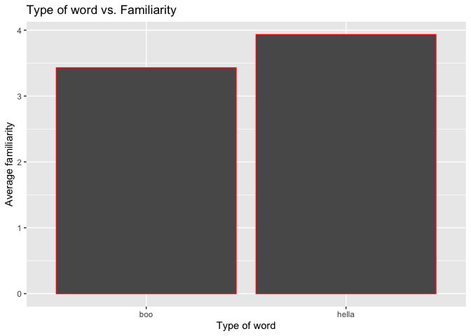

```r
#Graph

ggplot(data = comparison, aes(x = word, y=average_familiarity))+
  geom_bar(stat = "identity", color ="red")+
xlab("Type of word")+
ylab("Average familiarity")+
ggtitle("Type of word vs. Familiarity")
```

## Use the Data - part 3

```r
lets_find_bieber <-
  hiphop %>%
  select(subj, sex, age, ethnic, city, bieber) %>%
  distinct(subj, .keep_all = TRUE) %>%
  filter(city >= 10000 & city <=60000, age <=23 & age >=17, sex =="Male", ethnic =="white", bieber >=3)
lets_find_bieber
```

```
## # A tibble: 1 × 6
##   subj  sex     age ethnic  city bieber
##   <chr> <chr> <dbl> <chr>  <dbl>  <dbl>
## 1 p17   Male     18 white  56377      5
```